# Dataset generation: 2-CMT model with i.v. bolus dosing (Robbie PK model)

Niklas Hartung

2024-10-02

### Scope

Wwe consider a typical scenario for pharmacokinetics of monoclonal antibodies (following a paper by Robbie et al. Antimicrobial Agents and Chemotherapy, 2012):

- two-compartment model; multiple i.v. bolus dosing
- sparse sampling for some sampling intervals
- two continuous covariates: age and body weight

### Preliminaries

Required packages

```r
library(deSolve)
library(dplyr)
```

```r
library(ggplot2)
library(MASS)
```

Set a seed for reproducible results:

```r
set.seed(1)
```

Helper function to define a realistic body weight distribution for a certain age (Sumpter & Holford, Pediatr Anesth. 2011):

```r
sumpter <- function(age, sex = "m", iiv = TRUE) {

    FFEM_WTMAX <- ifelse(sex == "m", 1, 0.884)

    DPY <- 365.25  #day/year
    DPW <- 7       #day/week
    WPY <- DPY/DPW #week/year

    age <- age * WPY      # years --> weeks

    n <- length(age)

    pma <- age+40  #postmenstrual age [weeks] = postnatal age + 40 w gestation

    #parameters from Sumpter & Holford Pediatr Anesth. 2011
    WT_max1   <- 2.76     #kg
    TM50_WT1  <- 38.5     #weeks
    Hill1_WT1 <- 12.9
    Hill2_WT1 <- 2.74
    WT_max2   <- 16.4    #kg
    TM50_WT2  <- 2.10*WPY #weeks
    Hill1_WT2 <- 2.04
    Hill2_WT2 <- 1
    WT_max3   <- 40.2     #kg
    TM50_WT3  <- 12.4*WPY #weeks
    Hill1_WT3 <- 2.87
    Hill2_WT3 <- 0
    TLAG_WT4  <- TM50_WT3
    WT_max4   <- 33.6          #kg
    THALF_WT4 <- 3.61*WPY      #weeks
    THALF_PPV_AGE <- 3.52*WPY  #years to [weeks]

    RUV_CV <- 0.074

    #jointly simulate IIV parameters
    if (iiv) {
        corrmat <- matrix(data = c(1,     0.753, 0,0,-0.698,
                                   0.753, 1,     0,0,-0.957,
                                   0,     0,     1,0,0,
                                   0,     0,     0,1,0,
                                   -0.698,-0.957,0,0,1),
                          nrow = 5, ncol = 5)
        corrmat <- diag(rep(1,5))
        ppv_sd <- c(0.531, 0.388, 0.466, 0.245, 0.0572) #ppv_sd[5] 10 times smaller than in REF
        etas <- MASS::mvrnorm(n, mu = rep(0,5), Sigma = diag(ppv_sd)*corrmat*diag(ppv_sd))
    }

    #maturation process 1
    Hill_WT1 <- ifelse(pma < TM50_WT1, Hill1_WT1, Hill2_WT1)
    Fmat1 <- 1/(1+(TM50_WT1/pma)^Hill_WT1)
    WT1 <- Fmat1 * FFEM_WTMAX * WT_max1

    #maturation process 2
    Hill_WT2 <- ifelse(pma < TM50_WT2, Hill1_WT2, Hill2_WT2)
    Fmat2 <- 1/(1+(TM50_WT2/pma)^Hill_WT2)
    WT2 <- Fmat2 * WT_max2 # NOT * FFEM_WTMAX !

    #maturation process 3
    Hill_WT3 <- ifelse(pma < TM50_WT3, Hill1_WT3, Hill2_WT3)
    Fmat3 <- 1/(1+(TM50_WT3/pma)^Hill_WT3)
    WT3 <- Fmat3 * WT_max3 # NOT * FFEM_WTMAX !

    # weight 4
    WT4 <- ifelse(pma < TLAG_WT4,
                  0,
                  FFEM_WTMAX*WT_max4*(1-exp(-log(2)/THALF_WT4*(pma-TLAG_WT4))))

    if (iiv) {
        WT1 <- WT1 * exp(etas[ ,1])
        WT2 <- WT2 * exp(etas[ ,2])
        WT3 <- WT3 * exp(etas[ ,3])
        WT4 <- WT4 * exp(etas[ ,4])
    }
    BW <- WT1+WT2+WT3+WT4
    if (iiv) {
        IIV_ <- exp(-log(2)/THALF_PPV_AGE * pma)
        BW <- BW * exp(etas[ ,5] * IIV_)                #age-dependent variability
        BW <- BW * (1 + rnorm(length(BW), sd = RUV_CV)) #residual variability
    }
    return(BW)
}
```

### Model definition

Number of individuals (IDs)

```r
N <- 100
```

Covariate distribution:

- 50/50 split males/females
- uniform age between 0 and 20 years
- draw BW based on a realistic distribution

```r
sex <- rep(c("m","f"), length.out = N)
age <- runif(N, max = 20)
BW  <- sumpter(age = age, sex = sex)
```

Plotting the covariate distribution, for illustration

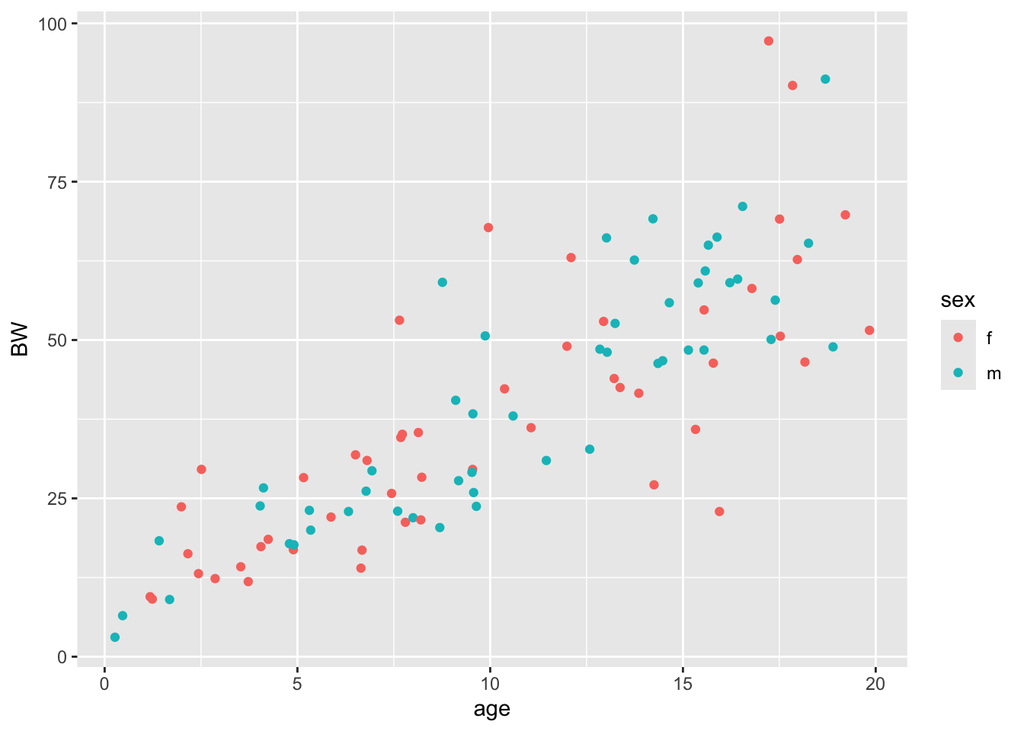

```r
ggplot() + geom_point(aes(x = age, y = BW, color = sex))
```

Dosing scheme: monthly body weight-normalized i.v. bolus doses

```r
reldose <- 15  # [mg/kg]
ndosing <- 5   #
interval <- 30 # [days] (monthly dosing)
D  <- vector(mode = "list", length = N)
tD <- seq(from = 0, by = interval, length = ndosing) # [days]
for (i in 1:N) {
    D[[i]] <- rep(BW[i] * reldose, times = ndosing)  # [mg]
}
route <- "iv_bolus"
```

Sampling times (rich sampling in first dosing interval, sparse thereafter)

```r
t_obs <- c(c(0.5,1,2,3,4,7,14,21), #  sampling times (in [days])
           interval + c(10,25),
           2*interval + c(10,25),
           3*interval + c(10,25),
           4*interval + c(10,25))
n_obs <- length(t_obs)             # number of samples
```

Hyperparameters:

- fixed effects `fe`
- standard deviation of random effects `sd_re`
- residual unexplained variability standard deviation `sd_ruv`

```r
fe <- c(CL   = 198,       # [mL/day]
        V1   = 4090,      # [mL]
        V2   = 2230,      # [mL]
        Q    = 879,       # [mL/day]
        beta = 1 - 0.411, # unitless
        TCL  = 62.3)      # [months]
sd_re <- c(V1 = 0.617,    # unitless
           CL = 0.487)    # unitless
sd_ruv <- 0.0639          # unitless, proportional error on linear scale
```

Individual parameters are affected by covariates:

- body weight on `V1`, `V2` and `Q`;
- body weight and age on `CL`

In addition, a log-normally distributed random effect (to ensure positivity) is applied to `CL` and `V1` (but not `V2` or `Q`).

```r
theta <- matrix(NA, nrow = N, ncol = 4, dimnames = list(NULL, c("CL","V1","Q","V2")))
for (i in 1:N) {

    relbw <- BW[i]/70
    mat <- 1 - fe[["beta"]] * exp(-(age[i]/4.35)*log(2)/fe[["TCL"]])

    theta[i,"CL"] <- fe[["CL"]] * relbw^0.75 * mat * rlnorm(n = 1, meanlog = 0, sdlog = sd_re[["CL"]])
    theta[i,"V1"] <- fe[["V1"]] * relbw * rlnorm(n = 1, meanlog = 0, sdlog = sd_re[["V1"]])
    theta[i,"Q"]  <- fe[["Q"]]  * relbw^0.75
    theta[i,"V2"] <- fe[["V2"]] * relbw

}
head(theta)
```

```
##            CL        V1        Q        V2
## [1,] 37.21178  812.2524 382.7909  736.0971
## [2,] 96.31648  623.3442 415.5395  821.2387
## [3,] 52.04313  295.1041 476.9616  986.9556
## [4,] 63.87746 3723.0835 647.0623 1482.2263
## [5,] 21.67979 2148.2857 391.3950  758.2401
## [6,] 93.70798 6692.2734 809.4021 1997.7393
```

ODE right-hand side

```r
rhs <- function(t, y, param) {
    # change from macro- to micro-parametrization
    ke  <- param[["CL"]]/param[["V2"]]
    k12 <- param[["Q"]] /param[["V1"]]
    k21 <- param[["Q"]] /param[["V2"]]

    # two-compartment ODEs
    dX <- c(
        k21 * y[["per"]] - (k12+ke) * y[["pla"]] ,
        k12 * y[["pla"]] - k21 * y[["per"]]
    )
    list(dX)
}
```

Solving ODE and computing model prediction:

```r
y_pred <- vector(mode = "list", length = N)
for (i in 1:N) {
    theta_i <- theta[i, ]
    x0 <- c(pla = 0, per = 0)

    # encoding repeated dosing via "events"
    eventdat <- data.frame(
        var  = "pla",
        time = tD,
        value = D[[i]],
        method = "add")

    # event times need to be included in ODE solver times
    t_ode <- sort(c(tD,t_obs))

    # ODE solution
    x_sol <- ode(y      = x0,
                 times  = t_ode,
                 func   = rhs,
                 parms  = theta_i,
                 events = list(data = eventdat) # handling of repeated dosing
                 )[t_ode %in% t_obs,"pla"]                    # remove dosing times from ode solution
    y_pred[[i]] <- x_sol / theta_i[["V1"]]
}
```

The (hierarchical) data:

```r
df <- data.frame(
    ID    = rep(1:N, each = n_obs),
    time  = rep(t_obs, times = N),
    y_obs = unlist(y_pred) *(1 + rnorm(n = N*n_obs, mean = 0, sd = sd_ruv)),
    dose  = NA,
    route = NA
) |>
    rbind(data.frame(
        ID = rep(1:N, each = ndosing),
        time = rep(tD, times = N),
        y_obs = NA,
        dose = unlist(D),
        route = route
    )) |>
    arrange(ID,time)
```

Peek at the data:

```r
head(df, n = 30)
```

```
##    ID  time      y_obs     dose    route
## 1   1   0.0         NA 346.5928 iv_bolus
## 2   1   0.5 0.34858919       NA     <NA>
## 3   1   1.0 0.29691798       NA     <NA>
## 4   1   2.0 0.21506715       NA     <NA>
## 5   1   3.0 0.17580996       NA     <NA>
## 6   1   4.0 0.19163943       NA     <NA>
## 7   1   7.0 0.16712570       NA     <NA>
## 8   1  14.0 0.14099118       NA     <NA>
## 9   1  21.0 0.11614792       NA     <NA>
## 10  1  30.0         NA 346.5928 iv_bolus
## 11  1  40.0 0.23396469       NA     <NA>
## 12  1  55.0 0.15960119       NA     <NA>
## 13  1  60.0         NA 346.5928 iv_bolus
## 14  1  70.0 0.28886157       NA     <NA>
```

[output cut: 16 more lines]

Visualization (just a subset of individuals, for easier visualization), including dosing cycles

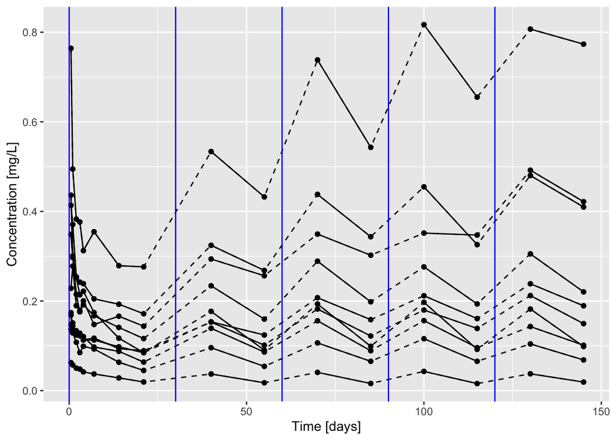

```r
ggplot(subset(df, ID <= 10),
       aes(x=time,y=y_obs,group = ID)) +
    geom_line() +
    geom_line(data = subset(df, ID <= 10 & !is.na(y_obs)), linetype = "dashed") +
    geom_point() +
    geom_vline(xintercept = tD, color = "blue") +
    xlab("Time [days]") +
    ylab("Concentration [mg/L]")
```

Write to file:

```r
write.csv(df, file = "../data/two-compartment-pk.csv")
```